# Reproducible Research: Peer Assessment 1

## Loading and preprocessing the data

This is the Programming Assignment for Week 2 of the Reproducible Research section of the Johns Hopkins University specialization in data science. For this project, we are looking data from fitness trackers. The code chunk below downloads, unzips, and reads in our data.

```r
download.file("https://d396qusza40orc.cloudfront.net/repdata%2Fdata%2Factivity.zip",
    destfile = "activity.zip")
unzip("activity.zip")
activity <- read.csv("activity.csv", na.strings = "NA")
```

## What is mean total number of steps taken per day?

The below code creates a histogram of the total steps taken in a day by the subject.

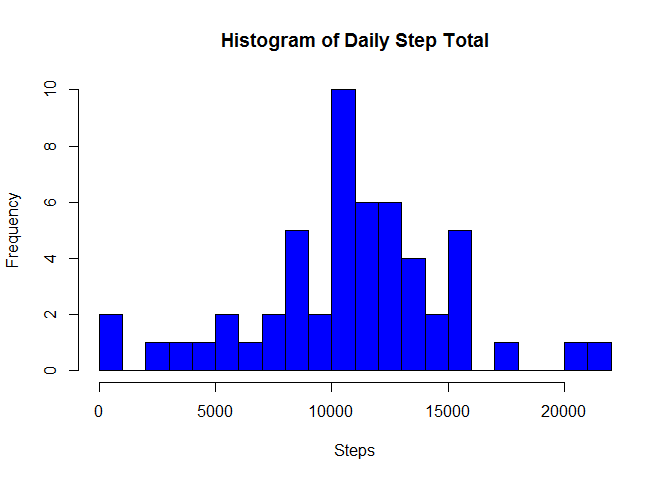

```r
daily.steps <- tapply(activity$steps,activity$date,sum)
hist(daily.steps, breaks = 20, col = 'blue', main = 'Histogram of Daily Step Total',
     xlab = 'Steps')
```

We are also interested in the **mean** and **median** for our subject’s total steps per day. The code below shows that those are 10,766.19 and 10,765, respectively.

```r
mean(daily.steps, na.rm = T)
```

```
## [1] 10766.19
```

```r
median(daily.steps, na.rm = T)
```

```
## [1] 10765
```

## What is the average daily activity pattern?

The plot below shows the average step count at each five-minute interval for the duration of the study.

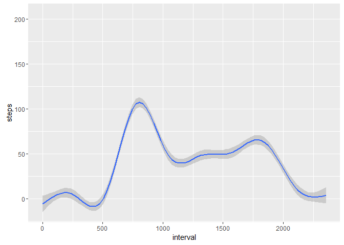

```r
library(ggplot2)
ggplot(data = activity[!is.na(activity$steps), ], aes(x = interval, y = steps)) +
    geom_smooth() + stat_summary(fun.y = mean, na.rm = TRUE)
```

```r
interval.trend <- tapply(activity$steps, activity$interval, mean, na.rm = TRUE)
max.avg <- max(interval.trend)
interval.trend[interval.trend == max.avg]
```

```
##      835
## 206.1698
```

## Imputing missing values

Since there are some time periods with null values, we need to deal with them in a way that makes sense. First, let’s see how many rows have null values for the `steps` variable.

```r
sum(is.na(activity$steps))
```

```
## [1] 2304
```

It appears that 2304 observations have a null value for `steps`. To handle this, we will impute the median number of steps for that five-minute interval and save the modified data frame as `imputed`.

```r
imputed <- activity
imputed$steps[is.na(imputed$steps)] <- with(imputed,
                                           ave(steps, interval,
                                           FUN = function(x)
                                           median(x, na.rm =
                                                  TRUE)))[is.na(imputed$steps)]
```

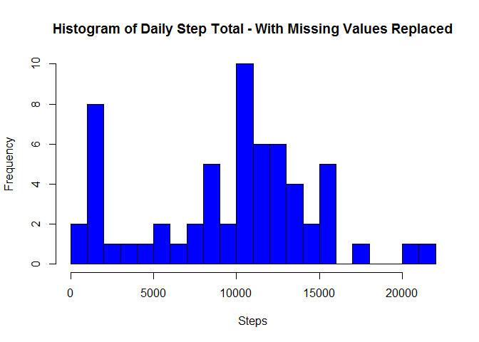

```r
imputed.steps <- tapply(imputed$steps,imputed$date,sum)
hist(imputed.steps, breaks = 20, col = 'blue',
     main = 'Histogram of Daily Step Total - With Missing Values Replaced',
     xlab = 'Steps')
```

The mean and median of the modified totals are now 9,503.869 and 10,395. The high volume of zeros imputed has shifted our daily totals down by quite a bit — this is due to the fact that null values are no longer ignored.

```r
mean(imputed.steps)
```

```
## [1] 9503.869
```

```r
median(imputed.steps)
```

```
## [1] 10395
```

## Are there differences in activity patterns between weekdays and weekends?

We’ll start by creating the factor variable to signify weekdays versus weekends.

```r
imputed$weekday <- ifelse(weekdays(as.Date(imputed$date)) %in% c('Saturday','Sunday'),
                          'weekend',
                          'weekday')
```

Next, we will split our data by weekend and weekday, giving the average number of steps taken during each interval for the days in the given category. We can see that the subject took the majority of his/her steps later in the day on the weekends, whereas the majority of weekday steps occur in the first few waking hours.

```r
library(grid)
library(gridExtra)
```

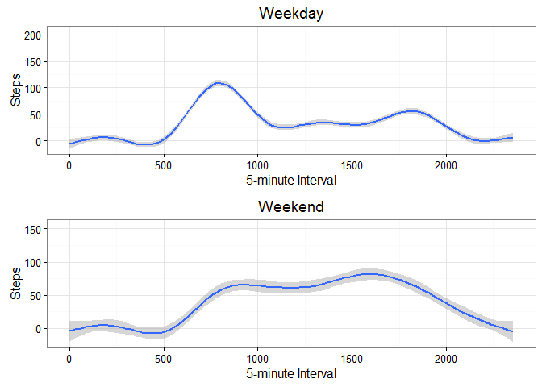

```r
plot_1 <- ggplot(data = imputed[imputed$weekday == "weekday", ], aes(x = interval,
    y = steps)) + theme_bw() + stat_summary(fun.y = mean, na.rm = T) + geom_smooth() +
    labs(x = "5-minute Interval", y = "Steps", title = "Weekday")

plot_2 <- ggplot(data = imputed[imputed$weekday != "weekday", ], aes(x = interval,
    y = steps)) + theme_bw() + stat_summary(fun.y = mean, na.rm = T) + geom_smooth() +
    labs(x = "5-minute Interval", y = "Steps", title = "Weekend")

grid.arrange(plot_1, plot_2, nrow = 2)
```